# Amazon Customer Review Analysis: Unlocking Insights into Consumer Satisfaction and Preferences

#### Imbalanced training data “train_df3_b2”

#### Balanced training data “train_df3_b2_balanced”

## Running logistic model on business question 2.

#### First using the imbalanced trainig data.

```r
str(train_df3_b2)
```

```
## 'data.frame':    23846 obs. of  11 variables:
##  $ reviews.doRecommend: logi  TRUE TRUE TRUE TRUE TRUE TRUE ...
##  $ Tblts              : num  1 1 1 1 1 1 1 1 1 1 ...
##  $ AmzDvcs            : num  0 0 0 0 0 0 0 0 0 0 ...
##  $ Accz               : num  0 0 0 0 0 0 0 0 0 0 ...
##  $ Elec               : num  0 0 0 0 0 0 0 0 0 0 ...
##  $ OffnBuss           : num  0 0 0 0 0 0 0 0 0 0 ...
##  $ snt_scr_text       : num  0.374 0.983 0.822 1.397 0.868 ...
##  $ snt_scr_title      : num  0 1 0 0.75 0.433 ...
##  $ snt_text_positive  : logi  TRUE TRUE TRUE TRUE TRUE TRUE ...
##  $ snt_title_positive : logi  FALSE TRUE FALSE TRUE TRUE TRUE ...
##  $ rating_is_5        : Factor w/ 2 levels "FALSE","TRUE": 2 2 2 1 2 2 1 2 2 2 ...
```

```r
# Run the logistic regression model
logit_model_rating5 <- glm(rating_is_5 ~ Tblts + Accz + AmzDvcs + Elec + OffnBuss + snt_scr_text + snt_scr_title,
                           family = binomial(link = "logit"), data = train_df3_b2)

# Display the summary of the model
summary(logit_model_rating5)
```

```
##
## Call:
## glm(formula = rating_is_5 ~ Tblts + Accz + AmzDvcs + Elec + OffnBuss +
##     snt_scr_text + snt_scr_title, family = binomial(link = "logit"),
##     data = train_df3_b2)
##
## Deviance Residuals:
##     Min       1Q   Median       3Q      Max
## -2.5019  -1.2740   0.7148   0.8967   1.5660
##
## Coefficients:
##               Estimate Std. Error z value Pr(>|z|)
## (Intercept)    0.44805    0.11784   3.802 0.000143 ***
## Tblts         -0.56488    0.11642  -4.852 1.22e-06 ***
## Accz          -0.07983    0.11965  -0.667 0.504680
## AmzDvcs       -0.28967    0.14808  -1.956 0.050449 .
## Elec           0.13914    0.12086   1.151 0.249657
## OffnBuss       0.43255    0.12767   3.388 0.000704 ***
## snt_scr_text   0.83548    0.03898  21.435  < 2e-16 ***
## snt_scr_title  0.57507    0.05082  11.316  < 2e-16 ***
## ---
## Signif. codes:  0 '***' 0.001 '**' 0.01 '*' 0.05 '.' 0.1 ' ' 1
##
## (Dispersion parameter for binomial family taken to be 1)
##
##     Null deviance: 29656  on 23845  degrees of freedom
## Residual deviance: 28356  on 23838  degrees of freedom
## AIC: 28372
##
## Number of Fisher Scoring iterations: 4
```

```r
# Predict probabilities for the validation dataset
validation_pred_probs <- predict(logit_model_rating5, newdata = validation_df3_b2, type = "response")

# Convert the probabilities to class labels using a threshold of 0.5
validation_pred_labels <- ifelse(validation_pred_probs > 0.5, "TRUE", "FALSE")

# Create a confusion matrix using the caret package

validation_actual_labels <- validation_df3_b2$rating_is_5
confusionMatrix(table(Predicted = validation_pred_labels, Actual = validation_actual_labels))
```

```
## Confusion Matrix and Statistics
##
##          Actual
## Predicted FALSE TRUE
##     FALSE   381  230
##     TRUE   2261 3941
##
##                Accuracy : 0.6344
##                  95% CI : (0.6228, 0.6458)
##     No Information Rate : 0.6122
##     P-Value [Acc > NIR] : 8.669e-05
##
##                   Kappa : 0.1037
##
##  Mcnemar's Test P-Value : < 2.2e-16
##
##             Sensitivity : 0.14421
##             Specificity : 0.94486
##          Pos Pred Value : 0.62357
##          Neg Pred Value : 0.63544
##              Prevalence : 0.38779
##          Detection Rate : 0.05592
##    Detection Prevalence : 0.08968
##       Balanced Accuracy : 0.54453
##
##        'Positive' Class : FALSE
##
```

#### Running Classification Tree on business q2 on imbalance dataset ‘train_df3_b2’

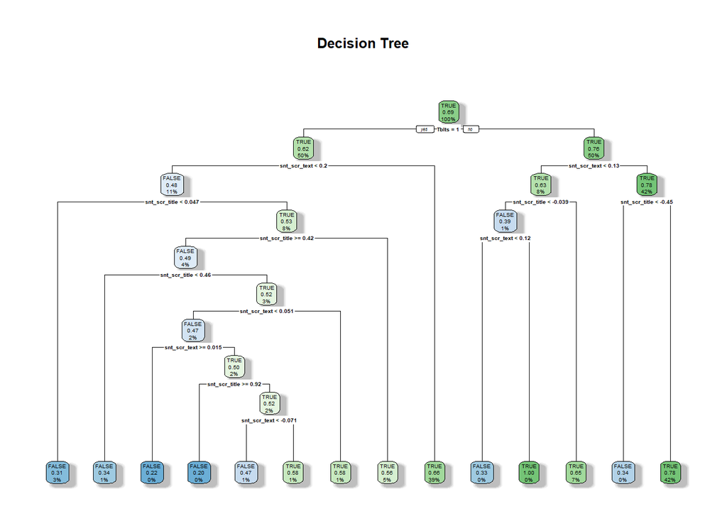

```r
# Train the decision tree model with a lower cp value
decision_tree_model <- rpart(rating_is_5 ~ Tblts + Accz + AmzDvcs + Elec + OffnBuss + snt_scr_text + snt_scr_title,
                             data = train_df3_b2, method = "class", control = rpart.control(cp = 0.001))

# Print the model summary
#print(decision_tree_model)
#
# # Plot the decision tree
# plot(decision_tree_model)
# text(decision_tree_model, use.n = TRUE, cex = 0.8)

# Load the rpart.plot package
library(rpart.plot)

# Plot the decision tree using rpart.plot
rpart.plot(decision_tree_model, box.palette = "auto", shadow.col = "gray", main = "Decision Tree")
```

#### Running Confusion Matrix on above Classification Tree

```r
# Predict probabilities using the decision tree model
predicted_probs <- predict(decision_tree_model, validation_df3_b2, type = "prob")

# Apply the cut-off point (0.6) to convert probabilities into binary predictions
cutoff_point <- 0.6
predicted_labels <- ifelse(predicted_probs[, "TRUE"] >= cutoff_point, TRUE, FALSE)

# Create a confusion matrix using the true labels and the predicted labels
true_labels <- validation_df3_b2$rating_is_5
confusion_matrix <- table(Predicted = predicted_labels, Actual = true_labels)

# Print the confusion matrix
print(confusion_matrix)
```

```
##          Actual
## Predicted FALSE TRUE
##     FALSE   787  732
##     TRUE   1855 3439
```

```r
# Load the caret package
library(caret)

# Calculate the confusion matrix
confusion_matrix <- confusionMatrix(as.factor(predicted_labels), as.factor(true_labels))

# Print the confusion matrix with metrics
print(confusion_matrix)
```

```
## Confusion Matrix and Statistics
##
##           Reference
## Prediction FALSE TRUE
##      FALSE   787  732
##      TRUE   1855 3439
##
##                Accuracy : 0.6203
##                  95% CI : (0.6086, 0.6318)
##     No Information Rate : 0.6122
##     P-Value [Acc > NIR] : 0.08756
##
##                   Kappa : 0.1327
##
##  Mcnemar's Test P-Value : < 2e-16
##
##             Sensitivity : 0.2979
##             Specificity : 0.8245
##          Pos Pred Value : 0.5181
##          Neg Pred Value : 0.6496
##              Prevalence : 0.3878
##          Detection Rate : 0.1155
##    Detection Prevalence : 0.2230
##       Balanced Accuracy : 0.5612
##
##        'Positive' Class : FALSE
##
```

#### Running Random-Forest on q2 on imbalance dataset ‘train_df3_b2’

```r
# Load the randomForest package
library(randomForest)

# Train the random forest model
rf_model <- randomForest(rating_is_5 ~ Tblts + Accz + AmzDvcs + Elec + OffnBuss + snt_scr_text + snt_scr_title, data = train_df3_b2)

# Print the model summary
print(rf_model)
```

```
##
## Call:
##  randomForest(formula = rating_is_5 ~ Tblts + Accz + AmzDvcs +      Elec + OffnBuss + snt_scr_text + snt_scr_title, data = train_df3_b2)
##                Type of random forest: classification
##                      Number of trees: 500
## No. of variables tried at each split: 2
##
##         OOB estimate of  error rate: 30.24%
## Confusion matrix:
##       FALSE  TRUE class.error
## FALSE   496  6978  0.93363661
## TRUE    232 16140  0.01417054
```

#### Running Confusion Matrix on above Random-Forest.

```r
# Predict the labels using the random forest model
predicted_labels_rf <- predict(rf_model, validation_df3_b2)

# Calculate the confusion matrix
confusion_matrix_rf <- confusionMatrix(as.factor(predicted_labels_rf), as.factor(validation_df3_b2$rating_is_5))

# Print the confusion matrix with metrics
print(confusion_matrix_rf)
```

```
## Confusion Matrix and Statistics
##
##           Reference
## Prediction FALSE TRUE
##      FALSE   271  125
##      TRUE   2371 4046
##
##                Accuracy : 0.6336
##                  95% CI : (0.6221, 0.6451)
##     No Information Rate : 0.6122
##     P-Value [Acc > NIR] : 0.0001419
##
##                   Kappa : 0.086
##
##  Mcnemar's Test P-Value : < 2.2e-16
##
##             Sensitivity : 0.10257
##             Specificity : 0.97003
##          Pos Pred Value : 0.68434
##          Neg Pred Value : 0.63051
##              Prevalence : 0.38779
##          Detection Rate : 0.03978
##    Detection Prevalence : 0.05812
##       Balanced Accuracy : 0.53630
##
##        'Positive' Class : FALSE
##
```

```r
library(pROC)

# True labels
true_labels <- validation_df3_b2$rating_is_5

# Logistic Regression
logit_probs <- predict(logit_model_rating5, validation_df3_b2, type = "response")
logit_roc <- roc(true_labels, logit_probs)
logit_df <- data.frame(Sensitivity = logit_roc$sensitivities,
                       Specificity = logit_roc$specificities,
                       Model = rep("Logistic Regression", length(logit_roc$sensitivities)))

# Decision Tree
dtree_probs <- predict(decision_tree_model, validation_df3_b2, type = "prob")[, "TRUE"]
dtree_roc <- roc(true_labels, dtree_probs)
dtree_df <- data.frame(Sensitivity = dtree_roc$sensitivities,
                       Specificity = dtree_roc$specificities,
                       Model = rep("Decision Tree", length(dtree_roc$sensitivities)))

# Random Forest
rforest_probs <- predict(rf_model, validation_df3_b2, type = "prob")[, "TRUE"]
rforest_roc <- roc(true_labels, rforest_probs)
```

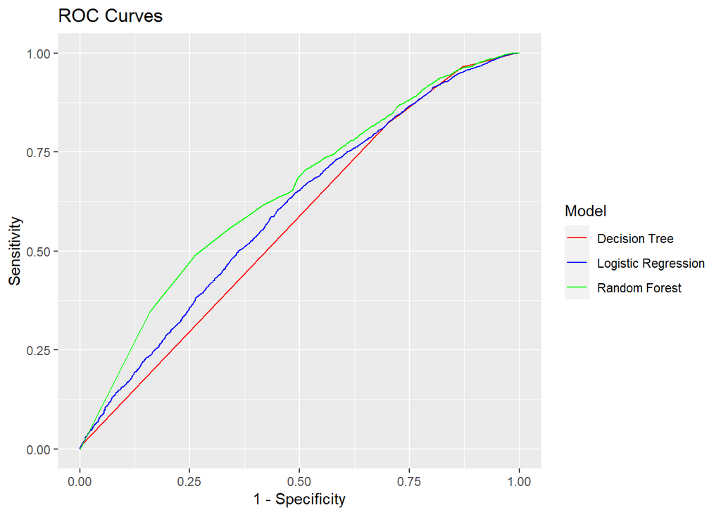

```r
rforest_df <- data.frame(Sensitivity = rforest_roc$sensitivities,
                         Specificity = rforest_roc$specificities,
                         Model = rep("Random Forest", length(rforest_roc$sensitivities)))

roc_df <- rbind(logit_df, dtree_df, rforest_df)

# Plot ROC curves
library(ggplot2)
ggplot(roc_df, aes(x = 1 - Specificity, y = Sensitivity, color = Model)) +
  geom_line() +
  labs(title = "ROC Curves",
       x = "1 - Specificity",
       y = "Sensitivity") +
  scale_color_manual(values = c("Logistic Regression" = "blue",
                                "Decision Tree" = "red",
                                "Random Forest" = "green"))
```

### Now using balanced trainig data to built logisitic model “train_df3_b2_balanced”

```r
str(train_df3_b2_balanced)
```

```
## 'data.frame':    42098 obs. of  11 variables:
##  $ reviews.doRecommend: logi  TRUE TRUE TRUE TRUE TRUE TRUE ...
##  $ Tblts              : num  1 1 1 1 1 1 1 1 1 1 ...
##  $ AmzDvcs            : num  0 0 0 0 0 0 0 0 0 0 ...
##  $ Accz               : num  0 0 0 0 0 0 0 0 0 0 ...
##  $ Elec               : num  0 0 0 0 0 0 0 0 0 0 ...
##  $ OffnBuss           : num  0 0 0 0 0 0 0 0 0 0 ...
##  $ snt_scr_text       : num  0.374 0.983 0.822 0.868 0.287 ...
##  $ snt_scr_title      : num  0 1 0 0.433 0.283 ...
##  $ snt_text_positive  : logi  TRUE TRUE TRUE TRUE TRUE TRUE ...
##  $ snt_title_positive : logi  FALSE TRUE FALSE TRUE TRUE TRUE ...
##  $ rating_is_5        : Factor w/ 2 levels "FALSE","TRUE": 2 2 2 2 2 2 2 2 2 2 ...
```

```r
table(train_df3_b2_balanced$rating_is_5)
```

```
##
## FALSE  TRUE
## 18710 23388
```

```r
# Run the logistic regression model
logit_model_rating5_balanced <- glm(rating_is_5 ~ reviews.doRecommend + Elec +Tblts + AmzDvcs + Accz + OffnBuss + snt_scr_text + snt_scr_title,
                                    family = binomial(link = "logit"), data = train_df3_b2_balanced)

# Display the summary of the model
summary(logit_model_rating5_balanced)
```

```
##
## Call:
## glm(formula = rating_is_5 ~ reviews.doRecommend + Elec + Tblts +
##     AmzDvcs + Accz + OffnBuss + snt_scr_text + snt_scr_title,
##     family = binomial(link = "logit"), data = train_df3_b2_balanced)
##
## Deviance Residuals:
##     Min       1Q   Median       3Q      Max
## -2.0139  -1.1996   0.7798   1.0264   2.8216
##
## Coefficients:
##                         Estimate Std. Error z value Pr(>|z|)
## (Intercept)             -3.40335    0.15299 -22.246  < 2e-16 ***
## reviews.doRecommendTRUE  3.72405    0.12895  28.879  < 2e-16 ***
## Elec                     0.01689    0.08775   0.192  0.84737
## Tblts                   -0.67149    0.08472  -7.926 2.26e-15 ***
## AmzDvcs                 -0.35379    0.10866  -3.256  0.00113 **
## Accz                    -0.16938    0.08694  -1.948  0.05140 .
## OffnBuss                 0.29598    0.09197   3.218  0.00129 **
## snt_scr_text             0.63930    0.02792  22.901  < 2e-16 ***
## snt_scr_title            0.24738    0.03815   6.484 8.93e-11 ***
## ---
## Signif. codes:  0 '***' 0.001 '**' 0.01 '*' 0.05 '.' 0.1 ' ' 1
##
## (Dispersion parameter for binomial family taken to be 1)
##
##     Null deviance: 57839  on 42097  degrees of freedom
## Residual deviance: 52624  on 42089  degrees of freedom
## AIC: 52642
##
## Number of Fisher Scoring iterations: 6
```

#### Running Confusion Matrix on logisitc model ‘logit_model_rating5_balanced’

```r
# Predict the probabilities for the validation dataset
predicted_probs_balanced <- predict(logit_model_rating5_balanced, newdata = validation_df3_b2, type = "response")

# Convert the predicted probabilities into binary predictions (TRUE or FALSE) using a 0.5 threshold
predicted_rating5_balanced <- ifelse(predicted_probs_balanced > 0.5, "TRUE", "FALSE")

# Create a confusion matrix
confusion_matrix_balanced <- table(Predicted = predicted_rating5_balanced, Reference = validation_df3_b2$rating_is_5)
print(confusion_matrix_balanced)
```

```
##          Reference
## Predicted FALSE TRUE
##     FALSE  1457 1601
##     TRUE   1185 2570
```

```r
# Calculate confusion matrix statistics
caret::confusionMatrix(confusion_matrix_balanced)
```

```
## Confusion Matrix and Statistics
##
##          Reference
## Predicted FALSE TRUE
##     FALSE  1457 1601
##     TRUE   1185 2570
##
##                Accuracy : 0.5911
##                  95% CI : (0.5793, 0.6028)
##     No Information Rate : 0.6122
##     P-Value [Acc > NIR] : 0.9998
##
##                   Kappa : 0.1629
##
##  Mcnemar's Test P-Value : 3.767e-15
##
##             Sensitivity : 0.5515
##             Specificity : 0.6162
##          Pos Pred Value : 0.4765
##          Neg Pred Value : 0.6844
##              Prevalence : 0.3878
##          Detection Rate : 0.2139
##    Detection Prevalence : 0.4488
##       Balanced Accuracy : 0.5838
##
##        'Positive' Class : FALSE
##
```

### Running decison tree on business question :2 using balanced trainig data

#### First, find the best cp (complexity parameter) value using cross-validation:

```r
library(caret)
train_control <- trainControl(method = "cv", number = 10) # 10-fold cross-validation
grid <- expand.grid(cp = seq(0.001, 0.1, length.out = 20)) # Create a sequence of cp values to try

decision_tree_model_b2 <- train(
  rating_is_5 ~ reviews.doRecommend + Tblts + AmzDvcs + Accz + Elec + OffnBuss + snt_scr_text + snt_scr_title,
  data = train_df3_b2_balanced,
  method = "rpart",
  trControl = train_control,
  tuneGrid = grid
)

best_cp_train_df3_b2_balanced <- decision_tree_model_b2$bestTune$cp
best_cp_train_df3_b2_balanced
```

```
## [1] 0.001
```

#### training the decision tree model using the best cp value:

```r
library(rpart)
final_decision_tree_model_b2 <- rpart(
  rating_is_5 ~ reviews.doRecommend + Tblts + AmzDvcs + Accz + Elec + OffnBuss + snt_scr_text + snt_scr_title,
  data = train_df3_b2_balanced,
  method = "class",
  control = rpart.control(cp = best_cp_train_df3_b2_balanced)
)
```

#### Visualizing decision tree

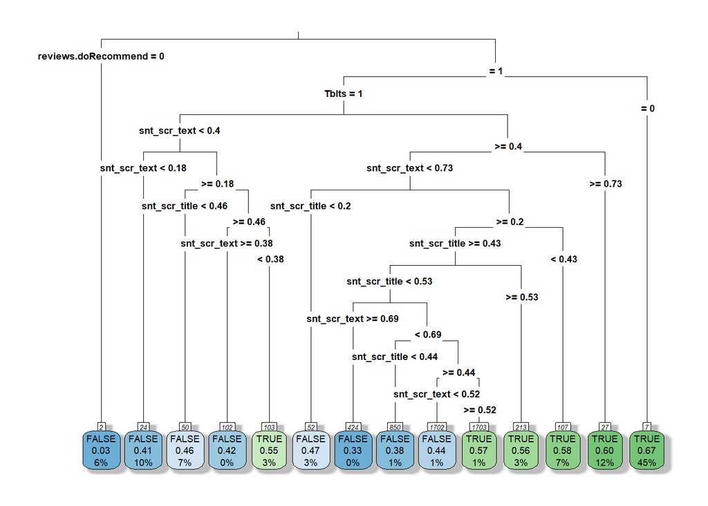

```r
library(rpart.plot)
rpart.plot(final_decision_tree_model_b2, type = 3, box.palette = "auto", fallen.leaves = TRUE, shadow.col = "gray", nn = TRUE)
```

#### Running Confusion Matrix on above classification Tree.

```r
val_predictions_b2 <- predict(final_decision_tree_model_b2, newdata = validation_df3_b2, type = "class")
val_predictions_b2 <- factor(val_predictions_b2, levels = c("FALSE", "TRUE"))
actual_values_b2 <- factor(validation_df3_b2$rating_is_5, levels = c("FALSE", "TRUE"))

conf_matrix_dt_b2 <- confusionMatrix(table(val_predictions_b2, actual_values_b2))
conf_matrix_dt_b2
```

```
## Confusion Matrix and Statistics
##
##                   actual_values_b2
## val_predictions_b2 FALSE TRUE
##              FALSE  1571 1667
##              TRUE   1071 2504
##
##                Accuracy : 0.5981
##                  95% CI : (0.5864, 0.6098)
##     No Information Rate : 0.6122
##     P-Value [Acc > NIR] : 0.9917
##
##                   Kappa : 0.1872
##
##  Mcnemar's Test P-Value : <2e-16
##
##             Sensitivity : 0.5946
##             Specificity : 0.6003
##          Pos Pred Value : 0.4852
##          Neg Pred Value : 0.7004
##              Prevalence : 0.3878
##          Detection Rate : 0.2306
##    Detection Prevalence : 0.4753
##       Balanced Accuracy : 0.5975
##
##        'Positive' Class : FALSE
##
```

### Running random-forest on business question 2. dataset ‘train_df3_b2_balanced’

```r
# Train the random forest model on the balanced training dataset
rf_model_b2 <- randomForest(rating_is_5 ~ ., data = train_df3_b2_balanced, importance = TRUE)

# Print the model summary
print(rf_model_b2)
```

```
##
## Call:
##  randomForest(formula = rating_is_5 ~ ., data = train_df3_b2_balanced,      importance = TRUE)
##                Type of random forest: classification
##                      Number of trees: 500
## No. of variables tried at each split: 3
##
##         OOB estimate of  error rate: 36.22%
## Confusion matrix:
##       FALSE  TRUE class.error
## FALSE  6368 12342   0.6596472
## TRUE   2904 20484   0.1241662
```

```r
# Predict the ratings on the validation dataset
val_predictions_b2_rf <- predict(rf_model_b2, newdata = validation_df3_b2)

# Create a confusion matrix
actual_values_b2 <- validation_df3_b2$rating_is_5
conf_matrix_b2_rf <- confusionMatrix(val_predictions_b2_rf, actual_values_b2)
print(conf_matrix_b2_rf)
```

```
## Confusion Matrix and Statistics
##
##           Reference
## Prediction FALSE TRUE
##      FALSE  1126 1040
##      TRUE   1516 3131
##
##                Accuracy : 0.6248
##                  95% CI : (0.6132, 0.6363)
##     No Information Rate : 0.6122
##     P-Value [Acc > NIR] : 0.01661
##
##                   Kappa : 0.1829
##
##  Mcnemar's Test P-Value : < 2e-16
##
##             Sensitivity : 0.4262
##             Specificity : 0.7507
##          Pos Pred Value : 0.5199
##          Neg Pred Value : 0.6738
##              Prevalence : 0.3878
##          Detection Rate : 0.1653
##    Detection Prevalence : 0.3179
##       Balanced Accuracy : 0.5884
##
##        'Positive' Class : FALSE
##
```

#### Building ROC curve to evaluate models built for business uestion 2.

```r
# True labels
true_labels_b2 <- validation_df3_b2$rating_is_5

# Logistic Regression
logit_probs_b2 <- predict(logit_model_rating5_balanced, validation_df3_b2, type = "response")
logit_roc_b2 <- roc(true_labels_b2, logit_probs_b2)
logit_df_b2 <- data.frame(Sensitivity = logit_roc_b2$sensitivities,
                          Specificity = logit_roc_b2$specificities,
                          Model = rep("Logistic Regression", length(logit_roc_b2$sensitivities)))

# Decision Tree
dtree_probs_b2 <- predict(final_decision_tree_model_b2, validation_df3_b2, type = "prob")[, "TRUE"]
dtree_roc_b2 <- roc(true_labels_b2, dtree_probs_b2)
dtree_df_b2 <- data.frame(Sensitivity = dtree_roc_b2$sensitivities,
                          Specificity = dtree_roc_b2$specificities,
                          Model = rep("Decision Tree", length(dtree_roc_b2$sensitivities)))

# Random Forest
rforest_probs_b2 <- predict(rf_model_b2, validation_df3_b2, type = "prob")[, "TRUE"]
rforest_roc_b2 <- roc(true_labels_b2, rforest_probs_b2)
```

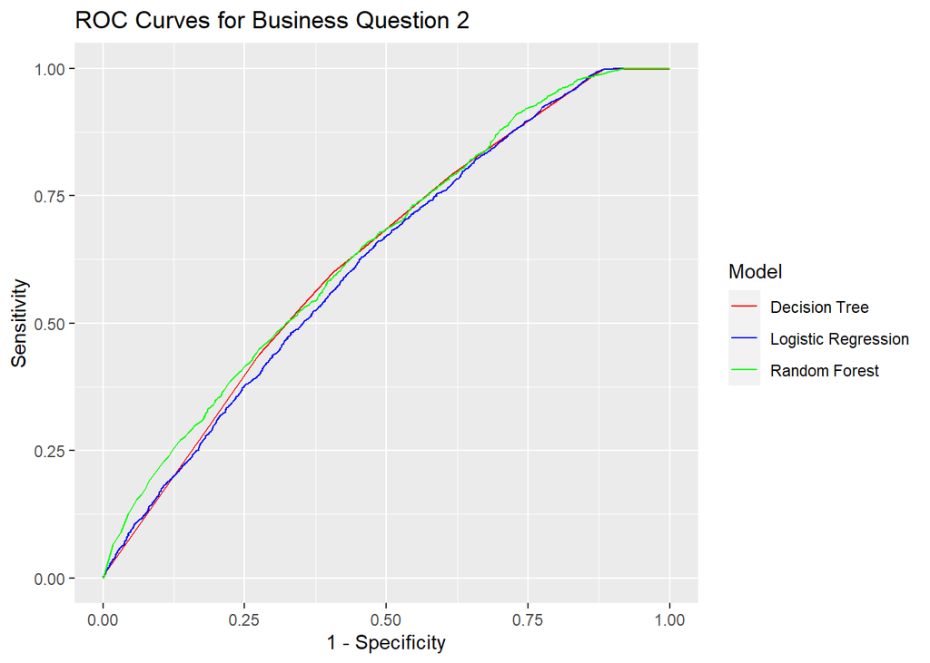

```r
rforest_df_b2 <- data.frame(Sensitivity = rforest_roc_b2$sensitivities,
                            Specificity = rforest_roc_b2$specificities,
                            Model = rep("Random Forest", length(rforest_roc_b2$sensitivities)))

roc_df_b2 <- rbind(logit_df_b2, dtree_df_b2, rforest_df_b2)

ggplot(roc_df_b2, aes(x = 1 - Specificity, y = Sensitivity, color = Model)) +
  geom_line() +
  labs(title = "ROC Curves for Business Question 2",
       x = "1 - Specificity",
       y = "Sensitivity") +
  scale_color_manual(values = c("Logistic Regression" = "blue",
                                "Decision Tree" = "red",
                                "Random Forest" = "green"))
```

#### Finding AUROC for models built for business question 2.

```r
logit_auc_b2 <- auc(logit_roc_b2)
dtree_auc_b2 <- auc(dtree_roc_b2)
rforest_auc_b2 <- auc(rforest_roc_b2)

cat("Logistic Regression AUROC for Business Question 2:", logit_auc_b2, "\n")
```

```
## Logistic Regression AUROC for Business Question 2: 0.6202656
```

```r
cat("Decision Tree AUROC for Business Question 2:", dtree_auc_b2, "\n")
```

```
## Decision Tree AUROC for Business Question 2: 0.6311551
```

```r
cat("Random Forest AUROC for Business Question 2:", rforest_auc_b2, "\n")
```

```
## Random Forest AUROC for Business Question 2: 0.6435429
```

## Business question 3:

### Predict which rating customer is gonna give 5, 4 or below 4 (3-1)?

#### Creating a new factor.variable ‘rating_category’ with three levels: ‘5’, ‘4’, and ‘below_4’.

#### Creating a new dataset df3_b3 for this business question in which incorporting this new dep var ‘rating_category’ and removing var ‘reviews.rating’.

```r
df3_b3 <- df3 %>%
  mutate(rating_category = case_when(
    reviews.rating == 5 ~ "5",
    reviews.rating == 4 ~ "4",
    TRUE ~ "below_4"
  ))

# Backup the original df3_b3 dataset
df3_b3_backup <- df3_b3

# Create the new df3_b3 dataset without the 'reviews.rating' variable
df3_b3 <- df3_b3 %>%
  select(-reviews.rating)


head(df3_b3)
```

```
##   reviews.doRecommend Tblts AmzDvcs Accz Elec OffnBuss snt_scr_text
## 1                TRUE     1       0    0    0        0    0.3744226
## 2                TRUE     1       0    0    0        0    0.9827076
## 3                TRUE     1       0    0    0        0    0.8221922
## 4                TRUE     1       0    0    0        0    1.3969270
## 5                TRUE     1       0    0    0        0    0.8682080
## 6                TRUE     1       0    0    0        0    0.2867697
##   snt_scr_title snt_text_positive snt_title_positive rating_category
## 1     0.0000000              TRUE              FALSE               5
## 2     1.0000000              TRUE               TRUE               5
## 3     0.0000000              TRUE              FALSE               5
## 4     0.7500000              TRUE               TRUE               4
## 5     0.4330127              TRUE               TRUE               5
## 6     0.2828427              TRUE               TRUE               5
```

```r
names(df3_b3)
```

```
##  [1] "reviews.doRecommend" "Tblts"               "AmzDvcs"
##  [4] "Accz"                "Elec"                "OffnBuss"
##  [7] "snt_scr_text"        "snt_scr_title"       "snt_text_positive"
## [10] "snt_title_positive"  "rating_category"
```

#### Partitioning the dataset ‘df3_b3’ 70-20-10.

```r
set.seed(123) # Set a seed for reproducibility

# Calculate the number of samples for each partition
n_total <- nrow(df3_b3)
n_train <- floor(0.7 * n_total)
n_val <- floor(0.2 * n_total)
n_test <- n_total - n_train - n_val

# Create a vector of indices for partitioning
indices <- sample(1:n_total)

# Partition the data
train_df3_b3 <- df3_b3[indices[1:n_train], ]
val_df3_b3 <- df3_b3[indices[(n_train + 1):(n_train + n_val)], ]
test_df3_b3 <- df3_b3[indices[(n_train + n_val + 1):n_total], ]

# Display the number of rows for each partition
cat("Training set rows:", nrow(train_df3_b3), "\n")
```

```
## Training set rows: 23844
```

```r
cat("Validation set rows:", nrow(val_df3_b3), "\n")
```

```
## Validation set rows: 6812
```

```r
cat("Testing set rows:", nrow(test_df3_b3), "\n")
```

```
## Testing set rows: 3408
```

#### Distribution of rating for var ‘rating_category’ b/w 5, 4 and below.

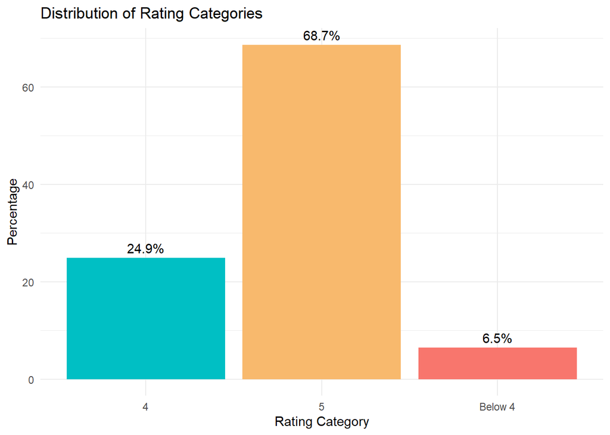

```r
# Calculate percentage for each category
rating_counts <- table(df3_b3$rating_category)
rating_percentages <- rating_counts / sum(rating_counts) * 100

# Create a data frame with rating categories and percentages
rating_data <- data.frame(
  category = names(rating_percentages),
  percentage = as.numeric(rating_percentages)
)

# Create a bar plot for the rating_category distribution with percentage labels and custom-colored bars
ggplot(rating_data, aes(x = category, y = percentage)) +
  geom_bar(stat = "identity", fill = c("#00BFC4", "#f8b96d", "#F8766D")) +
  geom_text(aes(label = paste0(round(percentage, 1), "%")), vjust = -0.5) +
  theme_minimal() +
  labs(title = "Distribution of Rating Categories",
       x = "Rating Category",
       y = "Percentage") +
  scale_x_discrete(labels = c("5" = "5", "4" = "4", "below_4" = "Below 4"))
```